# Part I - Prosper-Loan-Data-Analysis

## Introduction

> This data set contains inforamtion on loan amount, borrower rate, current loan status, borrower history etc. by credit company Prosper.

## Preliminary Wrangling

```python
#update seaborn and matplotlib
!pip install -U matplotlib seaborn
```

```python
# import all packages and set plots to be embedded inline
import numpy as np
import pandas as pd
import matplotlib.pyplot as plt
import seaborn as sb

%matplotlib inline
```

> Load in your dataset and describe its properties through the questions below. Try and motivate your exploration goals through this section.

```python
# Load dataset into pandas dataframe and print first five rows
df = pd.read_csv('prosperLoanData.csv')
df.head()
```

|  | ListingKey | ListingNumber | ListingCreationDate | CreditGrade | Term | LoanStatus | ClosedDate | BorrowerAPR | BorrowerRate | LenderYield | ... | LP_ServiceFees | LP_CollectionFees | LP_GrossPrincipalLoss | LP_NetPrincipalLoss | LP_NonPrincipalRecoverypayments | PercentFunded | Recommendations | InvestmentFromFriendsCount | InvestmentFromFriendsAmount | Investors |
| --- | --- | --- | --- | --- | --- | --- | --- | --- | --- | --- | --- | --- | --- | --- | --- | --- | --- | --- | --- | --- | --- |
| 0 | 1021339766868145413AB3B | 193129 | 2007-08-26 19:09:29.263000000 | C | 36 | Completed | 2009-08-14 00:00:00 | 0.16516 | 0.1580 | 0.1380 | ... | -133.18 | 0.0 | 0.0 | 0.0 | 0.0 | 1.0 | 0 | 0 | 0.0 | 258 |
| 1 | 10273602499503308B223C1 | 1209647 | 2014-02-27 08:28:07.900000000 | NaN | 36 | Current | NaN | 0.12016 | 0.0920 | 0.0820 | ... | 0.00 | 0.0 | 0.0 | 0.0 | 0.0 | 1.0 | 0 | 0 | 0.0 | 1 |
| 2 | 0EE9337825851032864889A | 81716 | 2007-01-05 15:00:47.090000000 | HR | 36 | Completed | 2009-12-17 00:00:00 | 0.28269 | 0.2750 | 0.2400 | ... | -24.20 | 0.0 | 0.0 | 0.0 | 0.0 | 1.0 | 0 | 0 | 0.0 | 41 |
| 3 | 0EF5356002482715299901A | 658116 | 2012-10-22 11:02:35.010000000 | NaN | 36 | Current | NaN | 0.12528 | 0.0974 | 0.0874 | ... | -108.01 | 0.0 | 0.0 | 0.0 | 0.0 | 1.0 | 0 | 0 | 0.0 | 158 |
| 4 | 0F023589499656230C5E3E2 | 909464 | 2013-09-14 18:38:39.097000000 | NaN | 36 | Current | NaN | 0.24614 | 0.2085 | 0.1985 | ... | -60.27 | 0.0 | 0.0 | 0.0 | 0.0 | 1.0 | 0 | 0 | 0.0 | 20 |

5 rows × 81 columns

```python
# summary of dataframe, number of rows and columns in the DataFrame, data types of each column
df.info()
```

```
<class 'pandas.core.frame.DataFrame'>
RangeIndex: 113937 entries, 0 to 113936
Data columns (total 81 columns):
 #   Column                               Non-Null Count   Dtype
---  ------                               --------------   -----
 0   ListingKey                           113937 non-null  object
 1   ListingNumber                        113937 non-null  int64
 2   ListingCreationDate                  113937 non-null  object
 3   CreditGrade                          28953 non-null   object
 4   Term                                 113937 non-null  int64
 5   LoanStatus                           113937 non-null  object
 6   ClosedDate                           55089 non-null   object
 7   BorrowerAPR                          113912 non-null  float64
 8   BorrowerRate                         113937 non-null  float64
 9   LenderYield                          113937 non-null  float64
```

[output cut: 73 more lines]

```python
# Number of rows and columns of dataset
df.shape
```

```
(113937, 81)
```

```python
# summary of the distribution of numeric data within the dataframe (e.g. count, mean, std, min, 25%, 50%, 75% and max)
df.describe()
```

|  | ListingNumber | Term | BorrowerAPR | BorrowerRate | LenderYield | EstimatedEffectiveYield | EstimatedLoss | EstimatedReturn | ProsperRating (numeric) | ProsperScore | ... | LP_ServiceFees | LP_CollectionFees | LP_GrossPrincipalLoss | LP_NetPrincipalLoss | LP_NonPrincipalRecoverypayments | PercentFunded | Recommendations | InvestmentFromFriendsCount | InvestmentFromFriendsAmount | Investors |
| --- | --- | --- | --- | --- | --- | --- | --- | --- | --- | --- | --- | --- | --- | --- | --- | --- | --- | --- | --- | --- | --- |
| count | 1.139370e+05 | 113937.000000 | 113912.000000 | 113937.000000 | 113937.000000 | 84853.000000 | 84853.000000 | 84853.000000 | 84853.000000 | 84853.000000 | ... | 113937.000000 | 113937.000000 | 113937.000000 | 113937.000000 | 113937.000000 | 113937.000000 | 113937.000000 | 113937.000000 | 113937.000000 | 113937.000000 |
| mean | 6.278857e+05 | 40.830248 | 0.218828 | 0.192764 | 0.182701 | 0.168661 | 0.080306 | 0.096068 | 4.072243 | 5.950067 | ... | -54.725641 | -14.242698 | 700.446342 | 681.420499 | 25.142686 | 0.998584 | 0.048027 | 0.023460 | 16.550751 | 80.475228 |
| std | 3.280762e+05 | 10.436212 | 0.080364 | 0.074818 | 0.074516 | 0.068467 | 0.046764 | 0.030403 | 1.673227 | 2.376501 | ... | 60.675425 | 109.232758 | 2388.513831 | 2357.167068 | 275.657937 | 0.017919 | 0.332353 | 0.232412 | 294.545422 | 103.239020 |
| min | 4.000000e+00 | 12.000000 | 0.006530 | 0.000000 | -0.010000 | -0.182700 | 0.004900 | -0.182700 | 1.000000 | 1.000000 | ... | -664.870000 | -9274.750000 | -94.200000 | -954.550000 | 0.000000 | 0.700000 | 0.000000 | 0.000000 | 0.000000 | 1.000000 |
| 25% | 4.009190e+05 | 36.000000 | 0.156290 | 0.134000 | 0.124200 | 0.115670 | 0.042400 | 0.074080 | 3.000000 | 4.000000 | ... | -73.180000 | 0.000000 | 0.000000 | 0.000000 | 0.000000 | 1.000000 | 0.000000 | 0.000000 | 0.000000 | 2.000000 |
| 50% | 6.005540e+05 | 36.000000 | 0.209760 | 0.184000 | 0.173000 | 0.161500 | 0.072400 | 0.091700 | 4.000000 | 6.000000 | ... | -34.440000 | 0.000000 | 0.000000 | 0.000000 | 0.000000 | 1.000000 | 0.000000 | 0.000000 | 0.000000 | 44.000000 |
| 75% | 8.926340e+05 | 36.000000 | 0.283810 | 0.250000 | 0.240000 | 0.224300 | 0.112000 | 0.116600 | 5.000000 | 8.000000 | ... | -13.920000 | 0.000000 | 0.000000 | 0.000000 | 0.000000 | 1.000000 | 0.000000 | 0.000000 | 0.000000 | 115.000000 |
| max | 1.255725e+06 | 60.000000 | 0.512290 | 0.497500 | 0.492500 | 0.319900 | 0.366000 | 0.283700 | 7.000000 | 11.000000 | ... | 32.060000 | 0.000000 | 25000.000000 | 25000.000000 | 21117.900000 | 1.012500 | 39.000000 | 33.000000 | 25000.000000 | 1189.000000 |

8 rows × 61 columns

```python
# randomly sample 100 rows from the DataFrame
df.sample(100)
```

|  | ListingKey | ListingNumber | ListingCreationDate | CreditGrade | Term | LoanStatus | ClosedDate | BorrowerAPR | BorrowerRate | LenderYield | ... | LP_ServiceFees | LP_CollectionFees | LP_GrossPrincipalLoss | LP_NetPrincipalLoss | LP_NonPrincipalRecoverypayments | PercentFunded | Recommendations | InvestmentFromFriendsCount | InvestmentFromFriendsAmount | Investors |
| --- | --- | --- | --- | --- | --- | --- | --- | --- | --- | --- | --- | --- | --- | --- | --- | --- | --- | --- | --- | --- | --- |
| 65142 | 216D349102761081423A101 | 470874 | 2010-08-10 15:47:37.680000000 | NaN | 36 | Completed | 2013-02-27 00:00:00 | 0.14152 | 0.0925 | 0.0825 | ... | -17.18 | 0.0 | 0.00 | 0.00 | 0.0 | 1.0000 | 0 | 0 | 0.0 | 103 |
| 86112 | E73F35893974716276B1878 | 917362 | 2013-09-21 12:35:49.013000000 | NaN | 60 | Current | NaN | 0.24754 | 0.2225 | 0.2125 | ... | -41.12 | 0.0 | 0.00 | 0.00 | 0.0 | 1.0000 | 0 | 0 | 0.0 | 1 |
| 75803 | C2B63395933685658ABBCC1 | 174477 | 2007-07-23 08:27:31.890000000 | B | 36 | Chargedoff | 2010-01-10 00:00:00 | 0.19730 | 0.1900 | 0.1700 | ... | -221.71 | 0.0 | 5466.48 | 5466.48 | 0.0 | 1.0000 | 0 | 0 | 0.0 | 164 |
| 1828 | 65DB36001474334340C1DB2 | 1156499 | 2014-01-24 07:17:14.767000000 | NaN | 36 | Current | NaN | 0.16324 | 0.1274 | 0.1174 | ... | -2.55 | 0.0 | 0.00 | 0.00 | 0.0 | 1.0000 | 0 | 0 | 0.0 | 1 |
| 80294 | F83835263345921302A4402 | 527639 | 2011-09-15 20:49:02.780000000 | NaN | 36 | Current | NaN | 0.35643 | 0.3199 | 0.3099 | ... | -87.64 | 0.0 | 0.00 | 0.00 | 0.0 | 0.9548 | 0 | 0 | 0.0 | 69 |
| ... | ... | ... | ... | ... | ... | ... | ... | ... | ... | ... | ... | ... | ... | ... | ... | ... | ... | ... | ... | ... | ... |
| 46010 | BA3F35281456747574BCFB1 | 529634 | 2011-09-27 06:41:02.920000000 | NaN | 36 | Completed | 2013-10-16 00:00:00 | 0.35643 | 0.3199 | 0.3099 | ... | -108.25 | 0.0 | 0.00 | 0.00 | 0.0 | 1.0000 | 0 | 0 | 0.0 | 113 |
| 64356 | 8F543430124497553C1ABC1 | 388449 | 2008-08-26 08:40:07.927000000 | C | 36 | Completed | 2011-09-04 00:00:00 | 0.29020 | 0.2669 | 0.2569 | ... | -61.46 | 0.0 | 0.00 | 0.00 | 0.0 | 1.0000 | 1 | 1 | 50.0 | 98 |
| 71052 | 8A973375284331530AC4EF0 | 67671 | 2006-11-28 14:34:50.780000000 | HR | 36 | Chargedoff | 2007-07-11 00:00:00 | 0.22744 | 0.2200 | 0.1950 | ... | -2.10 | 0.0 | 2401.55 | 2401.55 | 0.0 | 1.0000 | 0 | 0 | 0.0 | 24 |
| 43993 | 7CCC33663578544558B5A06 | 20016 | 2006-06-15 20:09:41.857000000 | A | 36 | Completed | 2009-06-27 00:00:00 | 0.09688 | 0.0900 | 0.0850 | ... | -41.09 | 0.0 | 0.00 | 0.00 | 0.0 | 1.0000 | 0 | 0 | 0.0 | 45 |
| 80737 | 8EF93595801415958751C66 | 1060256 | 2013-12-08 10:50:06.370000000 | NaN | 36 | Current | NaN | 0.11563 | 0.0879 | 0.0779 | ... | -16.88 | 0.0 | 0.00 | 0.00 | 0.0 | 1.0000 | 0 | 0 | 0.0 | 1 |

100 rows × 81 columns

### We are going to do some data assesing and cleaning before visualizations

```python
# Column that we will work with to create data visualizations
selected_columns = ['ListingCreationDate','ListingNumber','Term','LoanStatus','BorrowerAPR','BorrowerRate','ProsperRating (Alpha)',\
              'ProsperScore','ListingCategory (numeric)','BorrowerState','Occupation','EmploymentStatus','IsBorrowerHomeowner',\
              'CreditScoreRangeLower','CreditScoreRangeUpper','CurrentCreditLines','OpenRevolvingAccounts','DebtToIncomeRatio',\
              'IncomeRange','IncomeVerifiable','StatedMonthlyIncome','LoanOriginalAmount','LoanOriginationDate']
```

```python
df_new = df[selected_columns]
```

```python
df_new.head()
```

|  | ListingCreationDate | ListingNumber | Term | LoanStatus | BorrowerAPR | BorrowerRate | ProsperRating (Alpha) | ProsperScore | ListingCategory (numeric) | BorrowerState | ... | CreditScoreRangeLower | CreditScoreRangeUpper | CurrentCreditLines | OpenRevolvingAccounts | DebtToIncomeRatio | IncomeRange | IncomeVerifiable | StatedMonthlyIncome | LoanOriginalAmount | LoanOriginationDate |
| --- | --- | --- | --- | --- | --- | --- | --- | --- | --- | --- | --- | --- | --- | --- | --- | --- | --- | --- | --- | --- | --- |
| 0 | 2007-08-26 19:09:29.263000000 | 193129 | 36 | Completed | 0.16516 | 0.1580 | NaN | NaN | 0 | CO | ... | 640.0 | 659.0 | 5.0 | 1 | 0.17 | $25,000-49,999 | True | 3083.333333 | 9425 | 2007-09-12 00:00:00 |
| 1 | 2014-02-27 08:28:07.900000000 | 1209647 | 36 | Current | 0.12016 | 0.0920 | A | 7.0 | 2 | CO | ... | 680.0 | 699.0 | 14.0 | 13 | 0.18 | $50,000-74,999 | True | 6125.000000 | 10000 | 2014-03-03 00:00:00 |
| 2 | 2007-01-05 15:00:47.090000000 | 81716 | 36 | Completed | 0.28269 | 0.2750 | NaN | NaN | 0 | GA | ... | 480.0 | 499.0 | NaN | 0 | 0.06 | Not displayed | True | 2083.333333 | 3001 | 2007-01-17 00:00:00 |
| 3 | 2012-10-22 11:02:35.010000000 | 658116 | 36 | Current | 0.12528 | 0.0974 | A | 9.0 | 16 | GA | ... | 800.0 | 819.0 | 5.0 | 7 | 0.15 | $25,000-49,999 | True | 2875.000000 | 10000 | 2012-11-01 00:00:00 |
| 4 | 2013-09-14 18:38:39.097000000 | 909464 | 36 | Current | 0.24614 | 0.2085 | D | 4.0 | 2 | MN | ... | 680.0 | 699.0 | 19.0 | 6 | 0.26 | $100,000+ | True | 9583.333333 | 15000 | 2013-09-20 00:00:00 |

5 rows × 23 columns

```python
df_new.isnull().sum()
```

```
ListingCreationDate              0
ListingNumber                    0
Term                             0
LoanStatus                       0
BorrowerAPR                     25
BorrowerRate                     0
ProsperRating (Alpha)        29084
ProsperScore                 29084
ListingCategory (numeric)        0
BorrowerState                 5515
Occupation                    3588
EmploymentStatus              2255
IsBorrowerHomeowner              0
CreditScoreRangeLower          591
CreditScoreRangeUpper          591
CurrentCreditLines            7604
OpenRevolvingAccounts            0
DebtToIncomeRatio             8554
IncomeRange                      0
IncomeVerifiable                 0
StatedMonthlyIncome              0
LoanOriginalAmount               0
LoanOriginationDate              0
dtype: int64
```

```python
# check for duplicate data
sum(df_new.duplicated())
```

```
0
```

```python
# selecting not null rows of ProsperRating column since it is one of the most important column of the data

df_new = df_new[df_new['ProsperRating (Alpha)'].notnull()]
```

```python
df_new.info()
```

```
<class 'pandas.core.frame.DataFrame'>
Int64Index: 84853 entries, 1 to 113936
Data columns (total 23 columns):
 #   Column                     Non-Null Count  Dtype
---  ------                     --------------  -----
 0   ListingCreationDate        84853 non-null  object
 1   ListingNumber              84853 non-null  int64
 2   Term                       84853 non-null  int64
 3   LoanStatus                 84853 non-null  object
 4   BorrowerAPR                84853 non-null  float64
 5   BorrowerRate               84853 non-null  float64
 6   ProsperRating (Alpha)      84853 non-null  object
 7   ProsperScore               84853 non-null  float64
 8   ListingCategory (numeric)  84853 non-null  int64
 9   BorrowerState              84853 non-null  object
 10  Occupation                 83520 non-null  object
 11  EmploymentStatus           84853 non-null  object
 12  IsBorrowerHomeowner        84853 non-null  bool
 13  CreditScoreRangeLower      84853 non-null  float64
 14  CreditScoreRangeUpper      84853 non-null  float64
 15  CurrentCreditLines         84853 non-null  float64
 16  OpenRevolvingAccounts      84853 non-null  int64
 17  DebtToIncomeRatio          77557 non-null  float64
 18  IncomeRange                84853 non-null  object
 19  IncomeVerifiable           84853 non-null  bool
 20  StatedMonthlyIncome        84853 non-null  float64
 21  LoanOriginalAmount         84853 non-null  int64
 22  LoanOriginationDate        84853 non-null  object
dtypes: bool(2), float64(8), int64(5), object(8)
memory usage: 14.4+ MB
```

```python
#filling missing value
df_new['DebtToIncomeRatio'] = df_new['DebtToIncomeRatio'].fillna(df_new['DebtToIncomeRatio'].mean())
```

```python
df_new.info()
```

```
<class 'pandas.core.frame.DataFrame'>
Int64Index: 84853 entries, 1 to 113936
Data columns (total 23 columns):
 #   Column                     Non-Null Count  Dtype
---  ------                     --------------  -----
 0   ListingCreationDate        84853 non-null  object
 1   ListingNumber              84853 non-null  int64
 2   Term                       84853 non-null  int64
 3   LoanStatus                 84853 non-null  object
 4   BorrowerAPR                84853 non-null  float64
 5   BorrowerRate               84853 non-null  float64
 6   ProsperRating (Alpha)      84853 non-null  object
 7   ProsperScore               84853 non-null  float64
 8   ListingCategory (numeric)  84853 non-null  int64
 9   BorrowerState              84853 non-null  object
 10  Occupation                 83520 non-null  object
 11  EmploymentStatus           84853 non-null  object
 12  IsBorrowerHomeowner        84853 non-null  bool
 13  CreditScoreRangeLower      84853 non-null  float64
 14  CreditScoreRangeUpper      84853 non-null  float64
 15  CurrentCreditLines         84853 non-null  float64
 16  OpenRevolvingAccounts      84853 non-null  int64
 17  DebtToIncomeRatio          84853 non-null  float64
 18  IncomeRange                84853 non-null  object
 19  IncomeVerifiable           84853 non-null  bool
 20  StatedMonthlyIncome        84853 non-null  float64
 21  LoanOriginalAmount         84853 non-null  int64
 22  LoanOriginationDate        84853 non-null  object
dtypes: bool(2), float64(8), int64(5), object(8)
memory usage: 14.4+ MB
```

```python
df_new['Occupation'] = df_new['Occupation'].fillna('NaN')
```

```python
df_new.info()
```

```
<class 'pandas.core.frame.DataFrame'>
Int64Index: 84853 entries, 1 to 113936
Data columns (total 23 columns):
 #   Column                     Non-Null Count  Dtype
---  ------                     --------------  -----
 0   ListingCreationDate        84853 non-null  object
 1   ListingNumber              84853 non-null  int64
 2   Term                       84853 non-null  int64
 3   LoanStatus                 84853 non-null  object
 4   BorrowerAPR                84853 non-null  float64
 5   BorrowerRate               84853 non-null  float64
 6   ProsperRating (Alpha)      84853 non-null  object
 7   ProsperScore               84853 non-null  float64
 8   ListingCategory (numeric)  84853 non-null  int64
 9   BorrowerState              84853 non-null  object
 10  Occupation                 84853 non-null  object
 11  EmploymentStatus           84853 non-null  object
 12  IsBorrowerHomeowner        84853 non-null  bool
 13  CreditScoreRangeLower      84853 non-null  float64
 14  CreditScoreRangeUpper      84853 non-null  float64
 15  CurrentCreditLines         84853 non-null  float64
 16  OpenRevolvingAccounts      84853 non-null  int64
 17  DebtToIncomeRatio          84853 non-null  float64
 18  IncomeRange                84853 non-null  object
 19  IncomeVerifiable           84853 non-null  bool
 20  StatedMonthlyIncome        84853 non-null  float64
 21  LoanOriginalAmount         84853 non-null  int64
 22  LoanOriginationDate        84853 non-null  object
dtypes: bool(2), float64(8), int64(5), object(8)
memory usage: 14.4+ MB
```

```python
df_new.sample(100)
```

|  | ListingCreationDate | ListingNumber | Term | LoanStatus | BorrowerAPR | BorrowerRate | ProsperRating (Alpha) | ProsperScore | ListingCategory (numeric) | BorrowerState | ... | CreditScoreRangeLower | CreditScoreRangeUpper | CurrentCreditLines | OpenRevolvingAccounts | DebtToIncomeRatio | IncomeRange | IncomeVerifiable | StatedMonthlyIncome | LoanOriginalAmount | LoanOriginationDate |
| --- | --- | --- | --- | --- | --- | --- | --- | --- | --- | --- | --- | --- | --- | --- | --- | --- | --- | --- | --- | --- | --- |
| 35944 | 2012-12-27 13:08:38.467000000 | 691444 | 36 | Current | 0.32538 | 0.2859 | E | 4.0 | 7 | VA | ... | 640.0 | 659.0 | 11.0 | 7 | 0.13 | $75,000-99,999 | True | 7500.000000 | 4000 | 2012-12-31 00:00:00 |
| 35149 | 2013-05-15 09:58:50.557000000 | 780288 | 36 | Current | 0.14348 | 0.1153 | A | 6.0 | 1 | WY | ... | 780.0 | 799.0 | 14.0 | 11 | 0.30 | $100,000+ | True | 10416.666667 | 15000 | 2013-06-07 00:00:00 |
| 109864 | 2012-10-18 10:53:45.107000000 | 655991 | 60 | Completed | 0.22693 | 0.2024 | B | 8.0 | 1 | CA | ... | 740.0 | 759.0 | 8.0 | 6 | 0.19 | $1-24,999 | True | 1833.333333 | 2000 | 2012-10-23 00:00:00 |
| 28994 | 2012-07-24 18:46:47.367000000 | 616322 | 60 | Past Due (1-15 days) | 0.24682 | 0.2218 | C | 5.0 | 1 | NM | ... | 680.0 | 699.0 | 15.0 | 10 | 0.33 | $100,000+ | True | 9988.250000 | 15000 | 2012-07-31 00:00:00 |
| 54153 | 2013-07-23 03:03:50.543000000 | 847658 | 60 | Current | 0.14453 | 0.1219 | A | 8.0 | 1 | IN | ... | 760.0 | 779.0 | 15.0 | 10 | 0.36 | $75,000-99,999 | True | 6666.666667 | 15000 | 2013-08-20 00:00:00 |
| ... | ... | ... | ... | ... | ... | ... | ... | ... | ... | ... | ... | ... | ... | ... | ... | ... | ... | ... | ... | ... | ... |
| 41486 | 2013-05-07 12:21:57.220000000 | 771352 | 36 | Current | 0.28780 | 0.2492 | D | 3.0 | 1 | OH | ... | 660.0 | 679.0 | 7.0 | 7 | 0.28 | $25,000-49,999 | True | 3750.000000 | 10000 | 2013-05-13 00:00:00 |
| 21476 | 2013-11-14 07:01:11.530000000 | 1015457 | 36 | Current | 0.24205 | 0.2045 | C | 4.0 | 11 | GA | ... | 660.0 | 679.0 | 11.0 | 3 | 0.19 | $50,000-74,999 | True | 5325.000000 | 3000 | 2013-11-18 00:00:00 |
| 37855 | 2012-03-16 17:42:05.923000000 | 569532 | 36 | FinalPaymentInProgress | 0.17359 | 0.1449 | B | 8.0 | 3 | AZ | ... | 740.0 | 759.0 | 10.0 | 6 | 0.09 | $75,000-99,999 | True | 7324.000000 | 15000 | 2012-03-29 00:00:00 |
| 73549 | 2014-01-13 07:00:45.163000000 | 1128173 | 60 | Current | 0.25564 | 0.2304 | D | 2.0 | 1 | IL | ... | 700.0 | 719.0 | 9.0 | 5 | 0.22 | $75,000-99,999 | True | 7500.000000 | 10000 | 2014-01-15 00:00:00 |
| 1598 | 2009-10-02 05:35:37.387000000 | 426677 | 36 | Chargedoff | 0.28675 | 0.2635 | D | 8.0 | 7 | TX | ... | 680.0 | 699.0 | 6.0 | 2 | 0.16 | $50,000-74,999 | True | 5200.000000 | 4000 | 2009-10-08 00:00:00 |

100 rows × 23 columns

```python
# Convert ListingCreationDate type to datetime
df_new['ListingCreationDate'] = pd.to_datetime(df_new['ListingCreationDate'])

# Extract date from ListingCreationDate Column
df_new['date'] = df_new['ListingCreationDate'].dt.date

# Convert date to datetime
df_new['date'] =pd.to_datetime(df_new['date'])

# Extract year from ListingCreationDate Column
df_new['year'] = df_new['ListingCreationDate'].dt.year

#Extract month from ListingCreationDate Column
df_new['month'] = df_new['ListingCreationDate'].dt.month

# Dropping ListingCreationDate column since we don't need no more
df_new.drop(['ListingCreationDate'], axis=1, inplace=True)
```

```python
df_new.info()
```

```
<class 'pandas.core.frame.DataFrame'>
Int64Index: 84853 entries, 1 to 113936
Data columns (total 25 columns):
 #   Column                     Non-Null Count  Dtype
---  ------                     --------------  -----
 0   ListingNumber              84853 non-null  int64
 1   Term                       84853 non-null  int64
 2   LoanStatus                 84853 non-null  object
 3   BorrowerAPR                84853 non-null  float64
 4   BorrowerRate               84853 non-null  float64
 5   ProsperRating (Alpha)      84853 non-null  object
 6   ProsperScore               84853 non-null  float64
 7   ListingCategory (numeric)  84853 non-null  int64
 8   BorrowerState              84853 non-null  object
 9   Occupation                 84853 non-null  object
```

[output cut: 17 more lines]

```python
# Convert ListingNumber to str
df_new['ListingNumber'] = df_new['ListingNumber'].astype(str)

# Convert ProsperScore to int
df_new['ProsperScore'] = df_new['ProsperScore'].astype(int)

# Convert LoanOriginationDate type to datetime
df_new['LoanOriginationDate'] = pd.to_datetime(df_new['LoanOriginationDate'])

df_new.info()
```

```
<class 'pandas.core.frame.DataFrame'>
Int64Index: 84853 entries, 1 to 113936
Data columns (total 25 columns):
 #   Column                     Non-Null Count  Dtype
---  ------                     --------------  -----
 0   ListingNumber              84853 non-null  object
 1   Term                       84853 non-null  int64
 2   LoanStatus                 84853 non-null  object
 3   BorrowerAPR                84853 non-null  float64
 4   BorrowerRate               84853 non-null  float64
 5   ProsperRating (Alpha)      84853 non-null  object
 6   ProsperScore               84853 non-null  int32
 7   ListingCategory (numeric)  84853 non-null  int64
 8   BorrowerState              84853 non-null  object
 9   Occupation                 84853 non-null  object
```

[output cut: 17 more lines]

```python
df_new['ProsperRating (Alpha)'].unique()
```

```
array(['A', 'D', 'B', 'E', 'C', 'AA', 'HR'], dtype=object)
```

```python
ordered_rating = ['AA', 'A', 'B', 'C', 'D', 'E', 'HR']
ordered_type = pd.api.types.CategoricalDtype(categories = ordered_rating, ordered=True)
df_new['ProsperRating'] = df_new['ProsperRating (Alpha)'].astype(ordered_type)
df_new.drop(['ProsperRating (Alpha)'], axis=1, inplace=True)
```

```python
df_new['ProsperRating'].unique()
```

```
['A', 'D', 'B', 'E', 'C', 'AA', 'HR']
Categories (7, object): ['AA' < 'A' < 'B' < 'C' < 'D' < 'E' < 'HR']
```

```python
df_new['ListingCategory (numeric)'].unique()
```

```
array([ 2, 16,  1,  7, 13,  6, 15, 20, 19, 18,  3,  8, 11, 14,  9, 17, 10,
        0,  5, 12], dtype=int64)
```

```python
# got the dict info from the prosper data export website (https://www.prosper.com/Downloads/Services/Documentation/ProsperDataExport_Details.html)

category_dict = {0: 'Not available', 1: 'Debt consolidation', 2: 'Home improvement', 3: 'Business', 4: 'Personal loan',\
                 5: 'Student use', 6: 'Auto', 7: 'Other', 8: 'Baby & Adoption Loans', 9: 'Boat', 10: 'Cosmetic Procedures',\
                 11: 'Engagement Ring Financing', 12: 'Green Loans', 13: 'Household Expenses', 14: 'Large Purchases',\
                 15: 'Medical/Dental', 16: 'Motorcycle', 17: 'RV', 18: 'Taxes', 19: 'Vacation', 20: 'Wedding Loans'}
df_new['ListingCategory'] = df_new['ListingCategory (numeric)'].map(category_dict)
df_new.drop(['ListingCategory (numeric)'], axis=1, inplace=True)
```

```python
df_new['ListingCategory'].unique()
```

```
array(['Home improvement', 'Motorcycle', 'Debt consolidation', 'Other',
       'Household Expenses', 'Auto', 'Medical/Dental', 'Wedding Loans',
       'Vacation', 'Taxes', 'Business', 'Baby & Adoption Loans',
       'Engagement Ring Financing', 'Large Purchases', 'Boat', 'RV',
       'Cosmetic Procedures', 'Not available', 'Student use',
       'Green Loans'], dtype=object)
```

```python
df_new.info()
```

```
<class 'pandas.core.frame.DataFrame'>
Int64Index: 84853 entries, 1 to 113936
Data columns (total 25 columns):
 #   Column                 Non-Null Count  Dtype
---  ------                 --------------  -----
 0   ListingNumber          84853 non-null  object
 1   Term                   84853 non-null  int64
 2   LoanStatus             84853 non-null  object
 3   BorrowerAPR            84853 non-null  float64
 4   BorrowerRate           84853 non-null  float64
 5   ProsperScore           84853 non-null  int32
 6   BorrowerState          84853 non-null  object
 7   Occupation             84853 non-null  object
 8   EmploymentStatus       84853 non-null  object
 9   IsBorrowerHomeowner    84853 non-null  bool
```

[output cut: 17 more lines]

```python
df_new['LoanStatus'].value_counts()
```

```
Current                   56576
Completed                 19664
Chargedoff                 5336
Defaulted                  1005
Past Due (1-15 days)        806
Past Due (31-60 days)       363
Past Due (61-90 days)       313
Past Due (91-120 days)      304
Past Due (16-30 days)       265
FinalPaymentInProgress      205
Past Due (>120 days)         16
Name: LoanStatus, dtype: int64
```

```python
df_new.describe()
```

|  | Term | BorrowerAPR | BorrowerRate | ProsperScore | CreditScoreRangeLower | CreditScoreRangeUpper | CurrentCreditLines | OpenRevolvingAccounts | DebtToIncomeRatio | StatedMonthlyIncome | LoanOriginalAmount | year | month |
| --- | --- | --- | --- | --- | --- | --- | --- | --- | --- | --- | --- | --- | --- |
| count | 84853.000000 | 84853.000000 | 84853.000000 | 84853.000000 | 84853.000000 | 84853.000000 | 84853.000000 | 84853.000000 | 84853.000000 | 8.485300e+04 | 84853.000000 | 84853.000000 | 84853.000000 |
| mean | 42.486135 | 0.226658 | 0.196022 | 5.950067 | 699.390240 | 718.390240 | 10.508032 | 7.386292 | 0.258752 | 5.931175e+03 | 9083.440515 | 2012.328156 | 6.705785 |
| std | 11.640346 | 0.079916 | 0.074631 | 2.376501 | 47.095937 | 47.095937 | 5.317401 | 4.515977 | 0.304333 | 8.239944e+03 | 6287.860058 | 1.200926 | 3.664448 |
| min | 12.000000 | 0.045830 | 0.040000 | 1.000000 | 600.000000 | 619.000000 | 0.000000 | 0.000000 | 0.000000 | 0.000000e+00 | 1000.000000 | 2009.000000 | 1.000000 |
| 25% | 36.000000 | 0.163280 | 0.135900 | 4.000000 | 660.000000 | 679.000000 | 7.000000 | 4.000000 | 0.160000 | 3.434000e+03 | 4000.000000 | 2012.000000 | 3.000000 |
| 50% | 36.000000 | 0.219450 | 0.187500 | 6.000000 | 700.000000 | 719.000000 | 10.000000 | 7.000000 | 0.240000 | 5.000000e+03 | 7500.000000 | 2013.000000 | 7.000000 |
| 75% | 60.000000 | 0.292540 | 0.257400 | 8.000000 | 720.000000 | 739.000000 | 13.000000 | 10.000000 | 0.310000 | 7.083333e+03 | 13500.000000 | 2013.000000 | 10.000000 |
| max | 60.000000 | 0.423950 | 0.360000 | 11.000000 | 880.000000 | 899.000000 | 59.000000 | 50.000000 | 10.010000 | 1.750003e+06 | 35000.000000 | 2014.000000 | 12.000000 |

### What is the structure of your dataset?

> The dataframe consist of 84853 entries and 25 columns.Most data types are str and numerical type. All these types of data gives us loan and borrower information.

### What is/are the main feature(s) of interest in your dataset?

> I am interested in understanding the interest rate and APR of a loan, and the loan status. I have found that the range for interest rate is 0.1-0.36 and for APR is between 0.1-0.4, with APR being slightly higher than the interest rate. From loanstatus we can seen how many loans are completed, chargedoff or default. Additionally, I would like to know the main factors affecting the interest rate, the average interest rate on big and small loans, the size of loans taken out from Prosper, who typically takes out big and small loans, any differences in loans based on employment status, and which category of listing takes the most loans and for what purpose.

### What features in the dataset do you think will help support your investigation into your feature(s) of interest?

> From this dataset there are many features that can help us to answer our questions. To understand how interest rate is effected it would be the borrower information such as --> (CreditScore, IncomeRange, DebtToIncomeRatio, ProsperRating, StatedMonthlyIncome) that will help with our investigation. Along with these EmploymentStatus will also help us to understand loanStatus as well.

## Univariate Exploration

> In this section, I will investigate distributions of individual variables.

## Loan Status

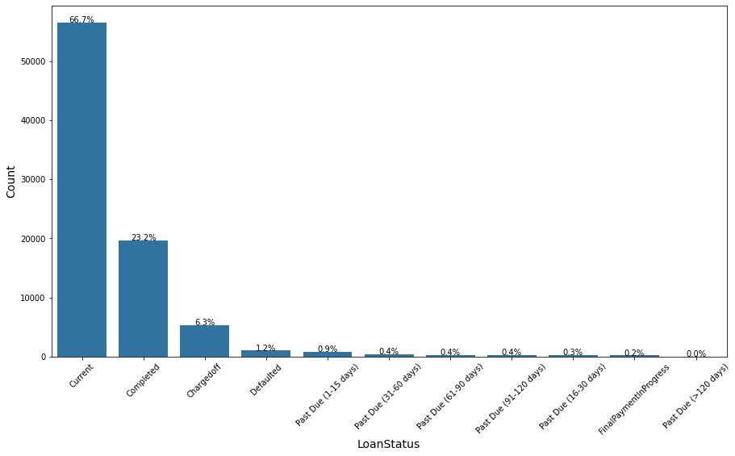

```python
plt.figure(figsize=(15,8))
base_color = sb.color_palette()[0]
loanstatus_order = df_new['LoanStatus'].value_counts().index
ax = sb.countplot(data=df_new, x='LoanStatus', color=base_color, order=loanstatus_order)
plt.xticks(rotation=45)
plt.xlabel('LoanStatus', fontsize=14)
plt.ylabel('Count', fontsize=14)
total = df_new.shape[0]
for i in range(df_new.LoanStatus.value_counts().shape[0]):
    count = df_new.LoanStatus.value_counts()[i]
    percent = '{:0.1f}%'.format(100*count/total)
    ax.text(i, count+10, percent, color='black', ha='center')
```

> We can see that there are lots of Past Due variables and it looks busy on the plot. So, i will aggregate those into only one past due varriable.

```python
# Create a list of loan status categories
loanstatus_dict = ['Current','Completed','Defaulted','Chargedoff','Past Due','FinalPaymentInProgress']

# Create a categorical data type with the loan status categories
loanstatus_order = pd.api.types.CategoricalDtype(categories = loanstatus_dict, ordered = True)

# Aggregate Past Due loans and convert LoanStatus to a categorical variable
df_new['LoanStatus'] = df_new['LoanStatus'].apply(lambda x: 'Past Due' if 'Past Due' in x else x)
df_new['LoanStatus'] = df_new['LoanStatus'].astype(loanstatus_order)
```

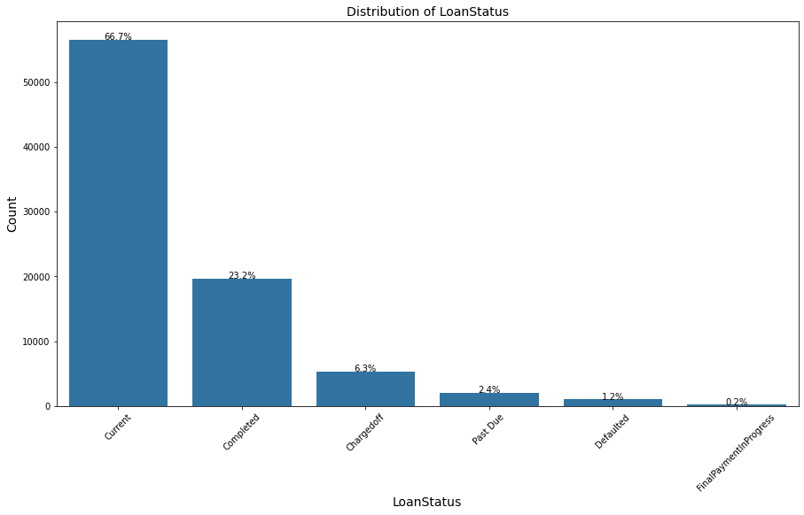

```python
plt.figure(figsize=(15,8))
loanstatus_order = df_new['LoanStatus'].value_counts().index
ax = sb.countplot(data=df_new, x='LoanStatus', color=base_color, order=loanstatus_order)
plt.xticks(rotation=45)
plt.xlabel('LoanStatus', fontsize=14)
plt.ylabel('Count', fontsize=14)
plt.title('Distribution of LoanStatus', fontsize=14)
total = df_new.shape[0]
for i in range(df_new.LoanStatus.value_counts().shape[0]):
    count = df_new.LoanStatus.value_counts()[i]
    percent = '{:0.1f}%'.format(100*count/total)
    ax.text(i, count+10, percent, color='black', ha='center')
```

> We can see from this new updated graph is that 66.7% are current and 23.2% are completed loans out of all prosper loans. However almost 8% of prosper's loan were either chargedoff or defaulted. After grouping all the past due together we see that it totals 2.4% of all loans.

## ProsperScore

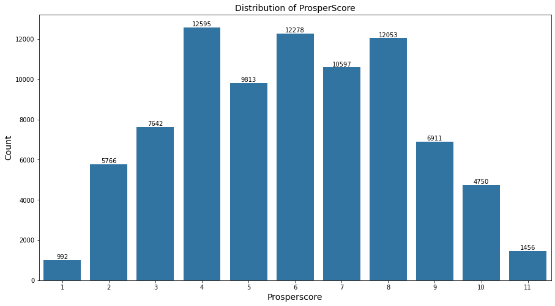

```python
plt.figure(figsize=(15,8))
base_color = sb.color_palette()[0]

ax = sb.countplot(data=df_new, x='ProsperScore', color=base_color)

plt.xlabel('Prosperscore', fontsize=14)
plt.ylabel('Count', fontsize=14)
plt.title('Distribution of ProsperScore', fontsize=14)

ax.bar_label(ax.containers[0], label_type='edge');
```

## BorrowerAPR & BorrowerRate

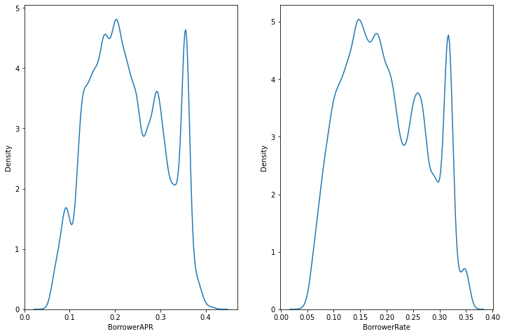

```python
plt.figure(figsize=(12,8))
plt.subplot(1,2,1)
sb.kdeplot(df_new.BorrowerAPR)
plt.subplot(1,2,2)
sb.kdeplot(df_new.BorrowerRate);
```

> We can see that BorrowerAPR is slightly higher than BorrowerRate. Which make sense becasue on the APR there is other fees such as mortgage, insurance, closing cost etc.

## ProsperRating

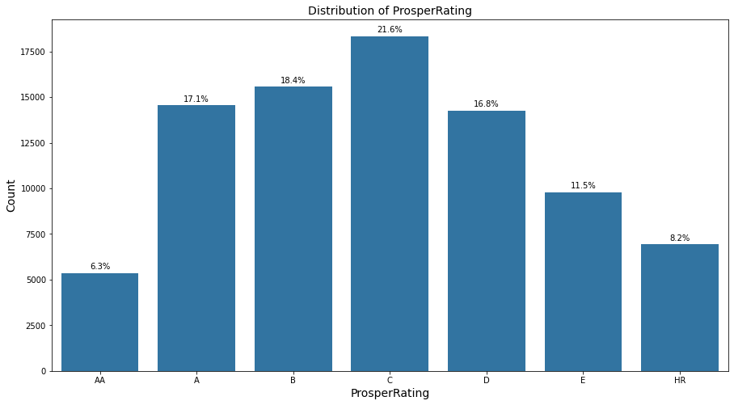

```python
plt.figure(figsize=(15,8))
ax = sb.countplot(data=df_new, x='ProsperRating', color=base_color)
plt.xlabel('ProsperRating', fontsize=14)
plt.ylabel('Count', fontsize=14)
plt.title('Distribution of ProsperRating', fontsize=14)
rating_count = df_new['ProsperRating'].value_counts()
location, label = plt.xticks()
total = df_new.shape[0]
for i,j in zip(location, label):
    count = rating_count[j.get_text()]
    percent = '{:0.1f}%'.format(100*count/total)
    ax.text(i, count+200, percent, color='black', ha='center')
```

> Prosper rating C has highest frequency with 21.6% of the total loans and rating AA has the lowest frequency with 6.3%

## Employment Status

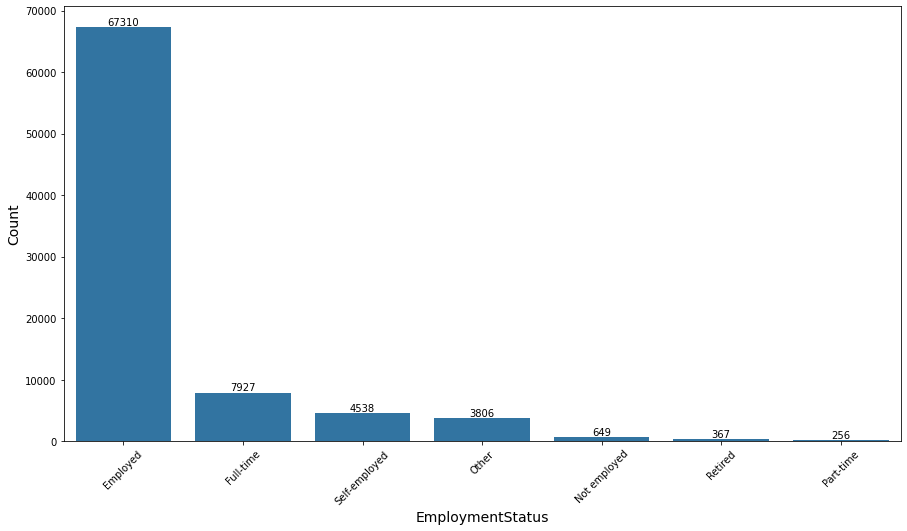

```python
plt.figure(figsize=(15,8))
status_order = df_new.EmploymentStatus.value_counts().index
ax = sb.countplot(data=df_new, x='EmploymentStatus', color=base_color, order=status_order)
plt.xticks(rotation=45)
plt.xlabel('EmploymentStatus', fontsize=14)
plt.ylabel('Count', fontsize=14)
ax.bar_label(ax.containers[0], label_type='edge');
```

> Most of the borrowers are employed, which we can see from the plot. This make sense because without a job getting loan wouldn't be easy. Another interesting thing we can see is that more non-employed people was issued loan than part-time job holder.

## Debt to Income Ratio

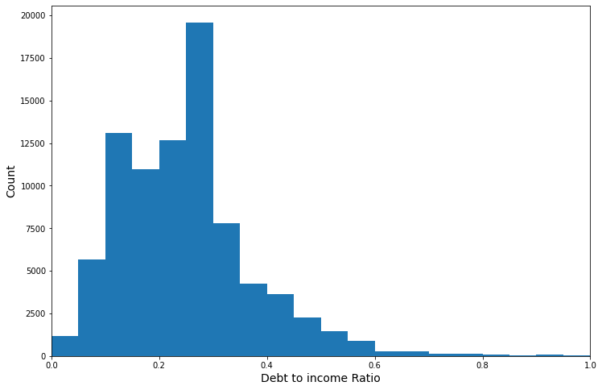

```python
plt.figure(figsize=(12,8))
bins = np.arange(0, df_new['DebtToIncomeRatio'].max()+0.05, 0.05)
plt.hist(data=df_new, x='DebtToIncomeRatio', bins=bins)
plt.xlabel('Debt to income Ratio', fontsize=14)
plt.ylabel('Count', fontsize=14)
plt.xlim(0,1);
```

> High debt to income ratio is when some has higher debt than they earn and low debt to income ratio is when someone has low debt compared to their income. From the plot we see that most prosper borrower's have debt to income ratio around 30%.

## Listing Category

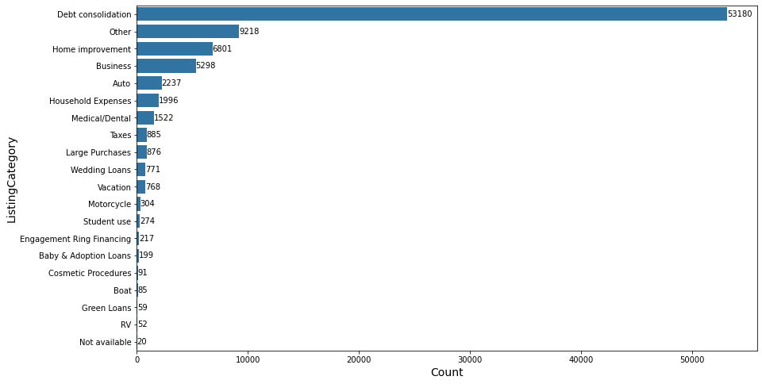

```python
plt.figure(figsize=(14,8))
category_order = df_new['ListingCategory'].value_counts().index
ax = sb.countplot(data=df_new, y='ListingCategory', color=base_color, order=category_order)
plt.ylabel('ListingCategory', fontsize=14)
plt.xlabel('Count', fontsize=14)
ax.bar_label(ax.containers[0], label_type='edge');
```

> From the plot we see that highest amount of prosper loans are debt consolidation type. Next popular types of loans are home improvement and business loans.

## Loan Term

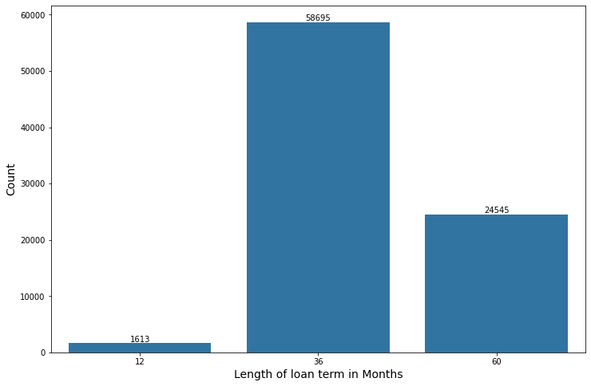

```python
plt.figure(figsize=(12,8))
ax = sb.countplot(data=df_new, x='Term', color=base_color)
plt.xlabel('Length of loan term in Months', fontsize=14)
plt.ylabel('Count', fontsize=14)
ax.bar_label(ax.containers[0], label_type='edge');
```

> Most common types of loan term is 36 months or 3 years followed by 60 months or 5 years. We can see very few borrowers has taken short term 12 months loan.

### Discuss the distribution(s) of your variable(s) of interest. Were there any unusual points? Did you need to perform any transformations?

> The loan status had many different past dues based on how many days past an specific loan was due. I aggregated all the past due varriables into one past due varriable.

### Of the features you investigated, were there any unusual distributions? Did you perform any operations on the data to tidy, adjust, or change the form of the data? If so, why did you do this?

> Most of the tidying and cleaning was to keep things in order such as maping values to listing category.

## Bivariate Exploration

> In this section, I will investigate relationships between pairs of variables in the data.

## Borrower Rate Over years

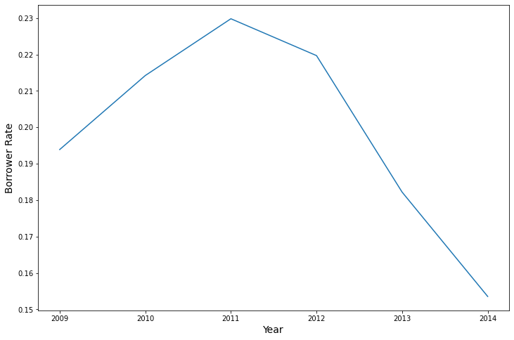

```python
plt.figure(figsize=(12,8))
sb.lineplot(data=df_new, x='year', y='BorrowerRate', errorbar=None)
plt.xlabel('Year', fontsize=14)
plt.ylabel('Borrower Rate', fontsize=14);
```

> From the plot we can see that borrower rate increased significantly in from 2009 to 2011 and started dropping from 2011 and sharply dropped from 2012.

## Relation between BorrowerRate, WageGroup, EmploymentStatus, and IsBorrowerHomeOwner

```python
plt.figure(figsize=(12,8))
bin_edges = [df_new['StatedMonthlyIncome'].min(), 3000, 7000, df_new['StatedMonthlyIncome'].max()]
df_new['WageGroup'] = pd.cut(df_new['StatedMonthlyIncome'], bin_edges, labels = ['Low', 'Medium', 'High'], include_lowest = True)
df_new['WageGroup'] = df_new['WageGroup'].cat.as_ordered();
```

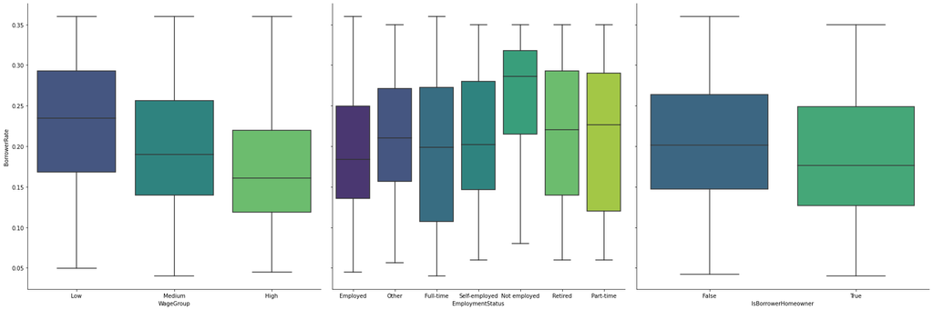

```python
#sb.boxplot(data=df_new, x='IsBorrowerHomeowner', y='BorrowerRate')

g = sb.PairGrid(data = df_new, x_vars=['WageGroup', 'EmploymentStatus', 'IsBorrowerHomeowner'], y_vars = ['BorrowerRate'], height=8, aspect=1, palette='viridis')
g.map(sb.boxplot);
```

> From the first plot we see that hihg income people have lower borrowrate than low income people. Also, that carry on to the employment status plot and we can see that employed people has lower rate while unemployed have highest borrow rate. And, people who own house they tend to have low rate as well than who don't own house.

## Relation between BorrowerRate, Prosper Score and Prosper Rating

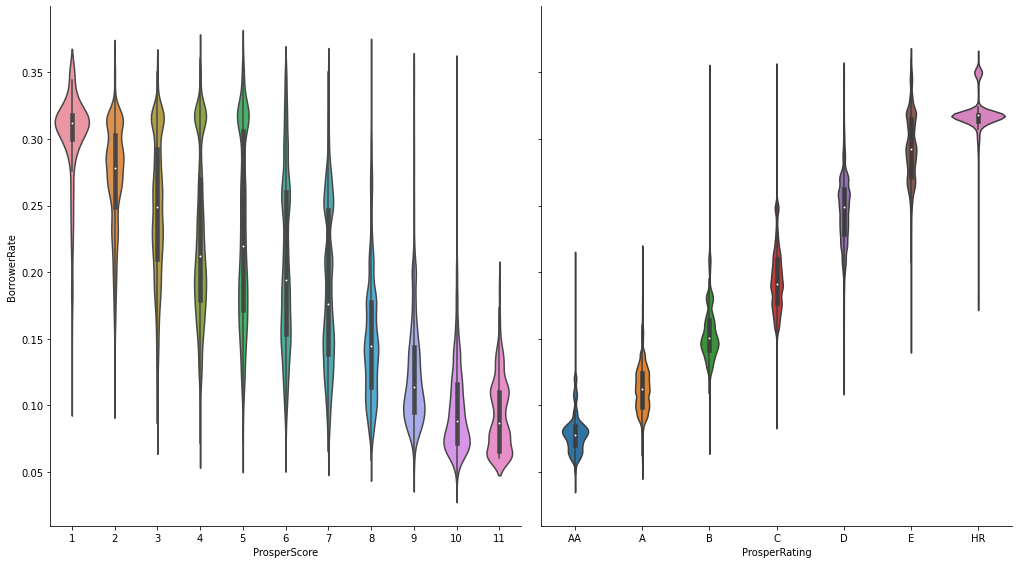

```python
g = sb.PairGrid(data = df_new, x_vars=['ProsperScore', 'ProsperRating'], y_vars = ['BorrowerRate'], height=8, aspect=.9)
g.map(sb.violinplot);
```

> From the plot we see that high prosper score borrower get loswer rate and lowest prosper score borrower get as high as 35% rate. Also, AA prosper rating borrower's get low rate while HR rating borrower's get high rate.

## Relation betwen BorrowerAPR and WageGroup, EmploymentStatus, IsBorrowerHomeOwner and others.

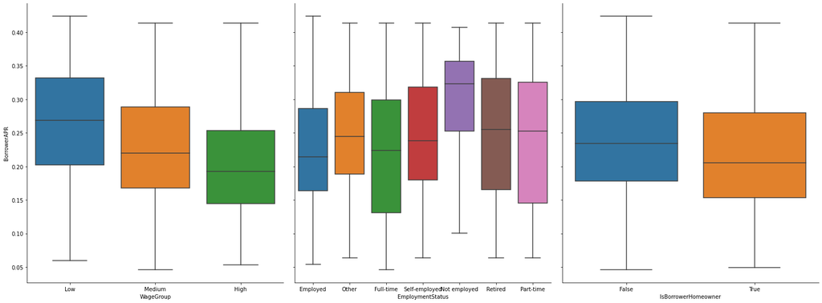

```python
g = sb.PairGrid(data = df_new, x_vars=['WageGroup', 'EmploymentStatus', 'IsBorrowerHomeowner'], y_vars = ['BorrowerAPR'], height=8, aspect=.9)
g.map(sb.boxplot);
```

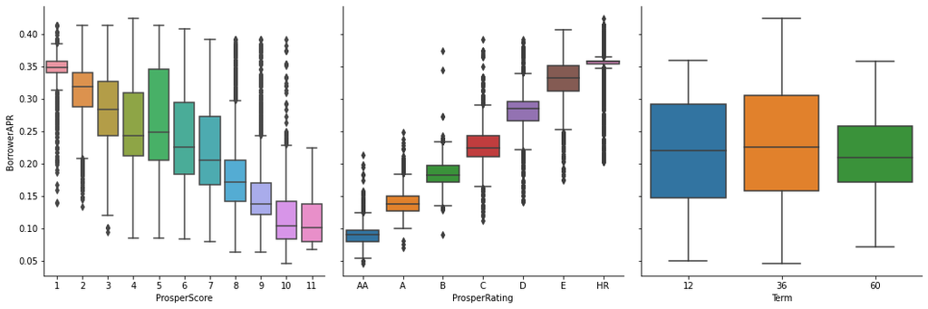

```python
g = sb.PairGrid(data = df_new, x_vars=['ProsperScore', 'ProsperRating', 'Term'], y_vars = ['BorrowerAPR'], height=5, aspect=1)
g.map(sb.boxplot);
```

### Talk about some of the relationships you observed in this part of the investigation. How did the feature(s) of interest vary with other features in the dataset?

> As i mostly focused on BorrowerRate and BorrowerAPR, we have seen people with high monthly salary, people with job, people with high prosper score, people with AA prosper rating gets the best borrowing rate and APR. On the other hand, people with part-time or unemployeed, low monthly salary, or non home owner, low prosper score and HR prosper rating tends to get high borrowing rate and APR.

## Borrower APR , Prosper rating and Loan status

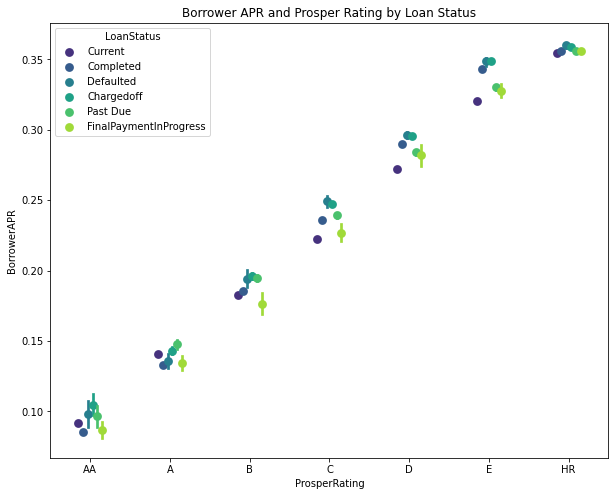

```python
plt.figure(figsize=(10,8))
ax = sb.pointplot(data = df_new, x='ProsperRating', y='BorrowerAPR', hue='LoanStatus', linestyles='', dodge=.3, palette='viridis')
plt.title('Borrower APR and Prosper Rating by Loan Status');
```

## Loan original amount and Income range by home owner status

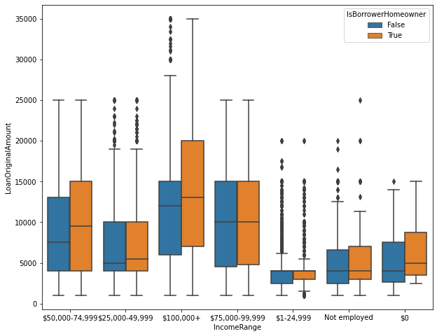

```python
plt.figure(figsize=(10,8))
sb.boxplot(data=df_new, x='IncomeRange', y='LoanOriginalAmount', hue='IsBorrowerHomeowner');
```

> We can see that high income range and a borrower is home owner their loan original amount is around 10k to 35K. Income 75k-99k and 50k-74k have alsmot similar loan original amount approved.

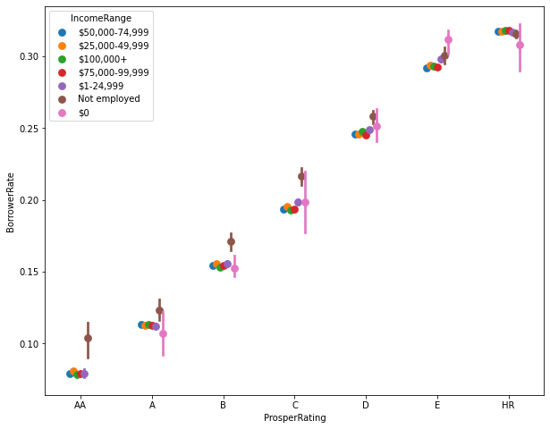

```python
plt.figure(figsize=(10,8))
ax = sb.pointplot(data=df_new, x='ProsperRating', y='BorrowerRate', hue='IncomeRange', linestyles='', dodge=.3);
```

> Good prosper rating such as AA and A along with any income level other than unemployed or 0 dollar listed all have low rate. Borrower with HR rating even with high income of 100k+ and 75k-99k income they have very high rate as well.

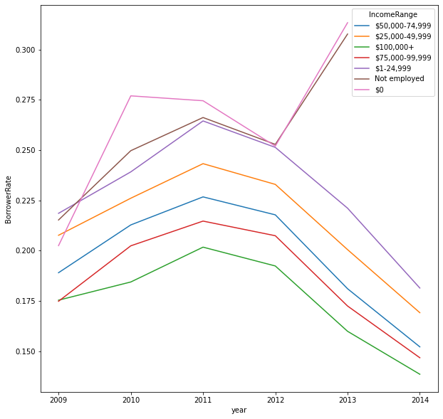

```python
plt.figure(figsize=(10,10))
g=sb.lineplot(data=df_new, x='year', y='BorrowerRate', hue='IncomeRange',errorbar=None);
```

### Talk about some of the relationships you observed in this part of the investigation. Were there features that strengthened each other in terms of looking at your feature(s) of interest?

> We have that how borrowing rate is effected based on prosper rating and loan status. Other than AA and A rating borrower and whose loan status is current they have low rate. whereas, other rating borrower's have high rate except whose status if finalpayment in progress.

> Borrower who is home owner and has income range they were approved larger original loan amount than whose income range is less than 25k, unemployeed or no income at all.

> other observation was that borrower with good prosper rating and high income range has lower rate than low income and bad prosper rating.